# Special Lecture: Mortality modelling. Introduction

20/5/2019

## Background

- Populations change through three processes: mortality, fertility, and migration.
- Changes in mortality contribute considerably to population dynamics and variation in the levels of mortality lead to changes in the age distribution of the population.
- This has repercussions on almost all areas of a society, including its health-care system, health and life insurance, as well as pension schemes.
- Demographic research investigates levels and trends of mortality, fertility and migration processes and develops numerous techniques to measure and analyze them

## Outline

- The first part reviews traditional and well-established models in mortality analysis.
- The fundamental Poisson assumption for the total number of deaths over a specified age- and year-interval will be introduced.
- Simple models for portraying mortality over age, and more sophisticated approaches for modeling mortality over both age and times will be reviewed in detail.

## Death rates

- To analyze mortality data, we have to make assumptions about the distribution of the random variable \(X\) and how it varies across individuals.
- The simplest assumption is that all individuals in one birth-cohort live their lives according to the same life-span distribution, hence, ignoring other sources of heterogeneity.
- The choice of the distribution is commonly based on the hazard rate.
- The traditional assumption is that the hazard is constant over each one-year age-interval. It is, however, different between ages. This “piece-wise constant” assumption is the basis for the calculation of empirical death rates.

## Death rates

- In general at age \(i\), during year \(j\) we define as death rate the following ratio: \(m_{ij}=\frac{Y_{ij}}{E_{ij}}\)
- where \(E_{ij}\) are the number of person-years aged \(i\) years during the year \(j\) and \(Y_{ij}\) are the number of deaths that occurred during the year \(j\) and attained age \(i\)
- The assumption of a constant hazard over short time intervals implies that the total number of deaths over a specifed age- and year-interval, \(Y_{ij}\), is a Poisson distribution with mean: \(Y_{ij} \sim Poisson(m_{ij}*E_{ij})\)
- (Poisson regression)

## Models

We have two alternative way to estimate \(μ(x)\):

1. let μ(x) free series of estimated death rates, (semi-parametric approach).
2. force μ(x) to follow a certain functional form, parametric models:

| Model | \(\mu(x)=\) |
| --- | --- |
| Gompertz(1825) | \(ae^{bx}\) |
| Makeham(1860) | \(c+ae^{bx}\) |
| Logistic(1932) | \(c+ \frac{ae^{bx}}{1+\alpha e^{bx}}\) |
| Weibull(1951) | \(\frac{1}{\sigma}(\frac{x}{M})^{\frac{M}{\sigma} -1}\) |
| Heligman-Pollard(1980) | \(A^{(x+b)^C} + De^{-E(\ln x- \ln F)^2}+GH^x\) |

## Gompertz

## Gompertz Model

- After almost 200 years, Benjamin Gompertz’ exponential formula remains the starting point for descriptions of the age trajectory of adult mortality rates in numerous species including our own.
- But it is only a starting point.
- Discoveries emerging from the measurement of hazard rates at advanced ages in large populations of model organisms as well as humans have now directed attention onto systematic deviations from Gompertz’ formula.

Density Function: \(f(X=x)=\alpha e^{\beta x}\exp[\frac{\alpha}{\beta}(1-e^{\beta x})]\)

Force of Mortality: \(\mu(x)=ae^{bx}\)

## Simulating and fitting Gompertz data

- Often it is useful to start with simulate data for understanding whether the estimation procedure is suitable and it does not contain bugs.
- The random variable we will simulate is the total number of death counts within a Lexis square.
- In order to use the Poisson framework, we need both the true hazard \(\mu(x)\) and a given exposure population \(E_x\) for each square (data available in the folder).

```r
expdata <- read.table("expdata.txt", header=TRUE)#dati
head(expdata)
```

```
##   ages    X
## 1   30 4892
## 2   31 4923
## 3   32 4960
## 4   33 5000
## 5   34 5041
## 6   35 5081
```

## Simulating and fitting Gompertz data

- Let us assume that we know the law that generated the true mortality rates (actually it is an unknown function).
- Therefore we assume that the force of mortality is modeled by a Gompertz with parameters \(a =0.00001\) and \(b = 0.1\).
- The slope parameter \(b\) of \(0.1\) is typical in human populations for adult ages from 30-85.

```r
set.seed(2)
a <- 0.00001
b <- 0.1

ages <- expdata[,1]
E <- expdata[,2]
m <- length(ages)

mx.true <- a * exp(b * ages)
```

- The random variable we will simulate is the total number of death counts.
- Through Poisson simulation, let’s compute the age-at-death distribution by using the true rates for each age. The means of the Poisson are given in the vector \(\mu(x)true * E_x\)

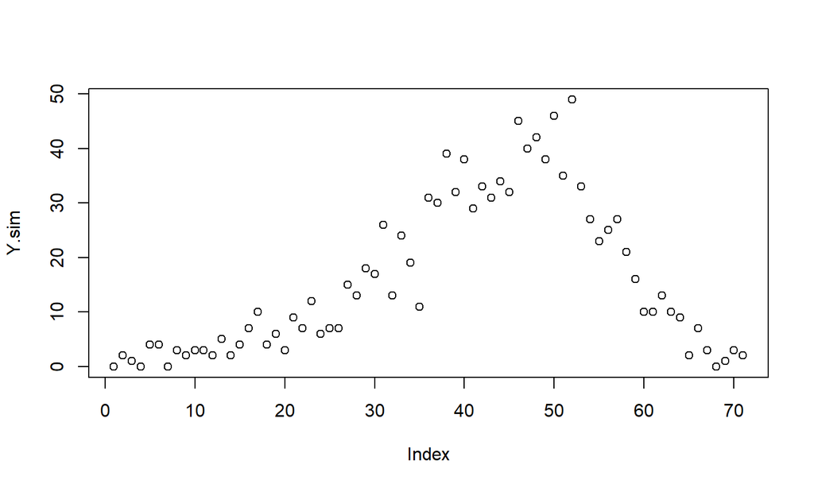

```r
mu<- mx.true * E
Y.sim <- rpois(m, lambda=mu)
plot(Y.sim)
```

- The main advantage of using a Poisson setting is the sum of real deaths is equal to the sum of the estimated ones.
- Starting from simulated Deaths count, let’s compute the simulated mortality rates. \(m_x(sim)= \frac{D_x(sim)}{E_x}\)

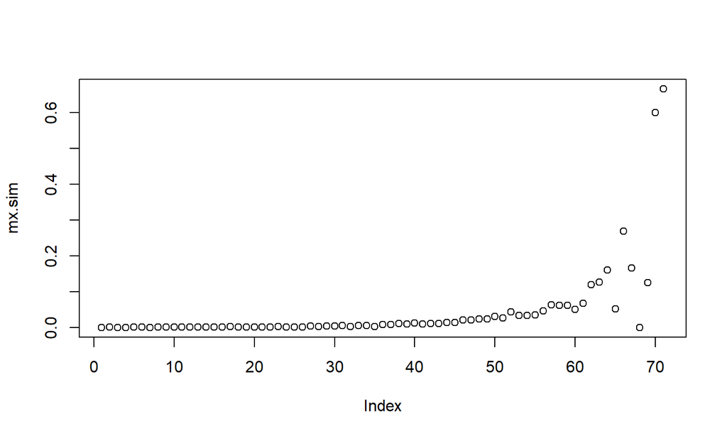

```r
mx.sim <- Y.sim / E
plot(mx.sim)
```

- Starting from Poisson Distribution assumption, It is usual to assume that the total number of deaths: \(Y_{x} \sim Poisson(\mu(x) E_x)\)
- Given a series of ages and deaths counts, we can treat the total number of deaths as if Poisson variables, with the log-likelihood:
  - \(\ln L(\theta) \propto \sum_{i=1}^m \{ y_i\ln[\lambda_i(\theta)]- \lambda_i(\theta) \}\)
- Where \(\theta\) are the parameters to estimate, \(\mu(x)= f(\theta,...,)\)
- Given \(Y_x\) and \(E_x\) , we maximize:
  - \(\ln L(a,b|Y_x,E_x) \propto \sum_{x} \{ y_x\ln[ae^{bx} E_x]- ae^{bx} E_x \}\)
  - \(\propto \sum_{x} \{ y_x\ln[ae^{bx}]- ae^{bx} E_x \}\)
- Make attention! We need to change the log-likelihood sign. The default optimization function in R minimizes the objective function while we need to maximize the log-likelihood.

```r
lnLLKgom <- function(theta, ages, Y, E){
  # parameters
  a <- theta[1]
  b <- theta[2]
  # Gompertz mu
  mu <- a * exp(b * ages)
  llk <- - sum(Y * log(mu) - mu*E)}
```

```r
st.val <- c(a,b)
fit <- optim(par=st.val,
             fn=lnLLKgom,
             ages=ages, Y=Y.sim, E=E)
a.hat <- fit$par[1]
b.hat <- fit$par[2]
```

## Standard Error

```r
a.hat
```

```
## [1] 9.933422e-06
```

```r
b.hat
```

```
## [1] 0.1001843
```

\(I(\theta)=-E \Big[\frac{\delta^2 \ln L(\theta)}{\delta\theta\delta\theta'}\Big] \approx H(\hat{\theta})\)

```r
library(nlme)
Hessian <- fdHess(pars=fit$par, fun=lnLLKgom,
ages=ages, Y=Y.sim, E=E)$Hessian
vcmat <- solve(Hessian)
se.theta <- sqrt(diag(vcmat))
```

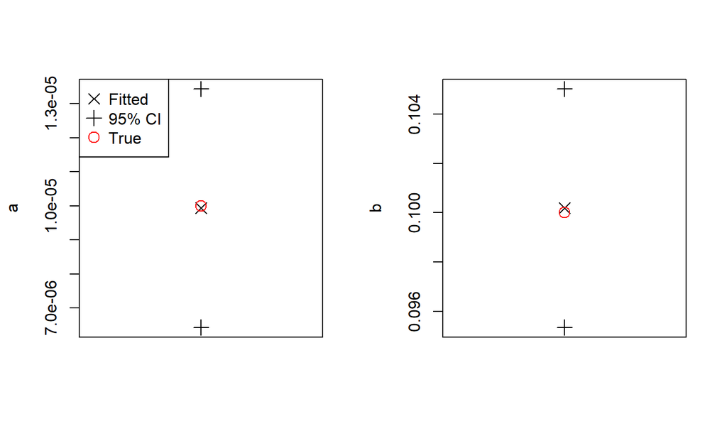

```r
as.hat <- c(a.hat-2*se.theta[1], a.hat, a.hat+2*se.theta[1])
bs.hat <- c(b.hat-2*se.theta[2], b.hat, b.hat+2*se.theta[2])
par(mfrow=c(1,2))
plot(rep(1,3), as.hat, cex=1.5,
ylab="a", xlab="", xaxt="n", pch=c(3,4,3))
points(1, a, col=2, pch=1, cex=1.5)
legend("topleft", c("Fitted", "95% CI", "True"),
col=c(1,1,2), pch=c(4,3,1), pt.cex=1.5)
plot(rep(1,3), bs.hat, cex=1.5,
ylab="b", xlab="", xaxt="n", pch=c(3,4,3))
points(1, b, col=2, pch=1, cex=1.5)
```

```r
par(mfrow=c(1,1))
```

```r
summary(m1 <- glm(Y.sim~ ages +offset(log(E)) ,family="poisson"))
```

```
##
## Call:
## glm(formula = Y.sim ~ ages + offset(log(E)), family = "poisson")
##
## Deviance Residuals:
##     Min       1Q   Median       3Q      Max
## -2.8527  -0.8117  -0.1659   0.7749   1.9533
##
## Coefficients:
##               Estimate Std. Error z value Pr(>|z|)
## (Intercept) -11.521101   0.175574  -65.62   <2e-16 ***
## ages          0.100202   0.002409   41.59   <2e-16 ***
## ---
## Signif. codes:  0 '***' 0.001 '**' 0.01 '*' 0.05 '.' 0.1 ' ' 1
##
## (Dispersion parameter for poisson family taken to be 1)
##
##     Null deviance: 2221.591  on 70  degrees of freedom
## Residual deviance:   85.047  on 69  degrees of freedom
## AIC: 372.57
##
## Number of Fisher Scoring iterations: 4
```

```r
library(MortalityLaws)
```

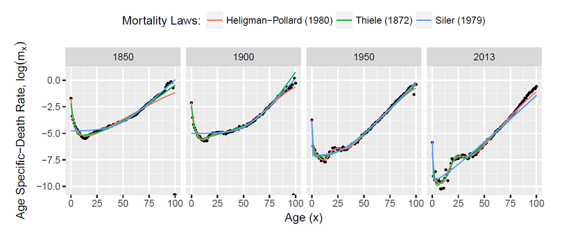

## Models

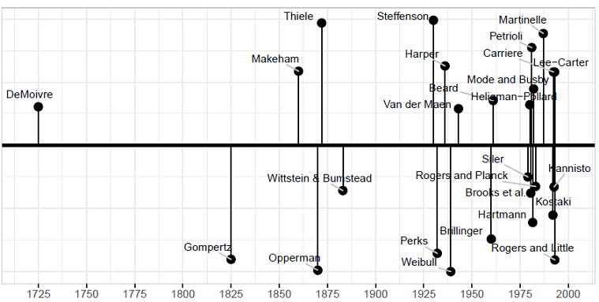

## Stochastic Models

## Stochastic Models

- Nowadays this latter approach represents the most widespread among scholars
- Thanks to its advantages just like the possibility to obtain a mortality surface as output
- One of the most used stochastic models is the Lee-Carter (1992)

## Simulating and fitting

- Let’s assume \(m(x)\) generated by a log-linear model Lee-Carter of which we know the parameters \(\alpha\), \(\beta\) and \(\kappa\). The “exposure” data are given
- We would like to investigate the Lee-Carter model ability to estimate the real parameters (in the real case supposed unknowns)

```r
AlphaTrue <- read.table("AlphaTrue.txt", header=TRUE)
head(AlphaTrue)
```

```
##   ages AlphaTrue
## 1   12 -8.372314
## 2   13 -8.203724
## 3   14 -8.052040
## 4   15 -7.918170
## 5   16 -7.801048
## 6   17 -7.698959
```

```r
BetaTrue <- read.table("BetaTrue.txt", header=TRUE)
head(BetaTrue)
```

```
##   ages   BetaTrue
## 1   12 0.01771880
## 2   13 0.01844355
## 3   14 0.01911838
## 4   15 0.01975053
## 5   16 0.02032102
## 6   17 0.02082565
```

```r
KappaTrue <- read.table("KappaTrue.txt", header=TRUE)
head(KappaTrue)
```

```
##   years KappaTrue
## 1  1930  62.01532
## 2  1931  60.81467
## 3  1932  59.55323
## 4  1933  58.23310
## 5  1934  56.85407
## 6  1935  55.42689
```

```r
ages <- AlphaTrue[,1]
years <- KappaTrue[,1]
aT <- AlphaTrue[,2]
bT <- BetaTrue[,2]
kT <- KappaTrue[,2]
n <- length(years)
m <- length(ages)
EXP <- as.matrix(read.table("Exposures.txt", header=TRUE))
```

- Generation of \(m(x)\) true

```r
One <- matrix(1, nrow=n, ncol=1)
MU.true <- exp(aT %*% t(One) + bT %*% t(kT))
D.true <- MU.true * EXP
```

- Using Poisson assumption, we can simulate \(D_x\) and \(m(x)\).
- We use the simulate \(m(x)\) in order to check model performance

```r
D.sim <- matrix(NA, m, n)
for(i in 1:n){
D.sim[,i] <- rpois(m, lambda=D.true[,i])
}
MU.sim <- D.sim / EXP
```

```r
## deaths
D <- D.sim
D[D==0] <- 1
## exposures
E <-EXP
E[E==0] <- 1
## log-rates
lMX <- log(D/E)
alpha.h <- apply(lMX, 1, mean)
## centering the log-death rates
cent.logMX <- sweep(lMX, 1, alpha.h)
## apply the SVD
SVD <- svd(cent.logMX)
## set and normalize beta and kappa
beta.h <- SVD$u[,1] / sum(SVD$u[,1])
kappa.h <- SVD$v[,1] * SVD$d[1] * sum(SVD$u[,1])
```

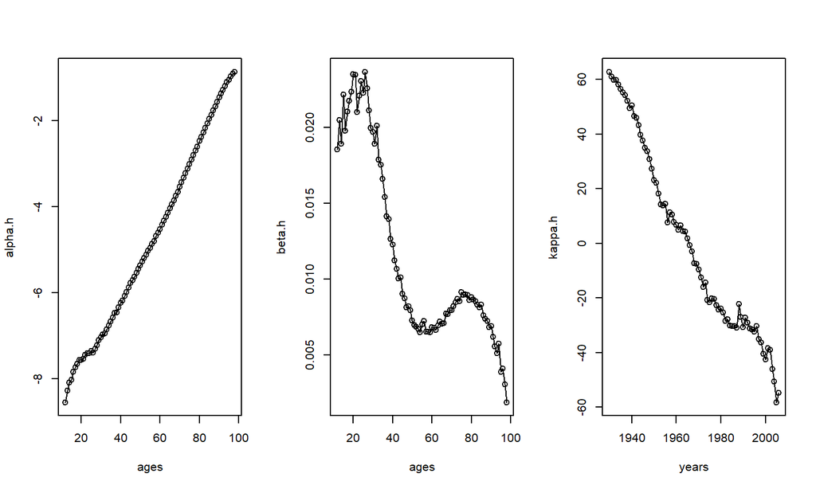

```r
par(mfrow=c(1,3))
plot(ages, alpha.h, t="o")
plot(ages, beta.h, t="o")
plot(years, kappa.h, t="o")
```

```r
par(mfrow=c(1,1))

## fitted log-mortality
One <- rep(1,n)
lMXhat <- alpha.h%*%t(One) + beta.h %*% t(kappa.h)
```

```r
par(mfrow=c(1,3))
plot(ages, alpha.h, t="l", lwd=3, col=4,
ylab=expression(alpha))
lines(ages, aT, lwd=2, col=2, lty=2)
legend("topleft", c("True", "Fitted"),
col=c(2,4), lty=c(2,1), lwd=c(2,3))
plot(ages, beta.h, t="l", lwd=3, col=4,
ylab=expression(beta))
lines(ages, bT, lwd=2, col=2, lty=2)
legend("topright", c("True", "Fitted"),
col=c(2,4), lty=c(2,1), lwd=c(2,3))
plot(years, kappa.h, t="l", lwd=3, col=4,
ylab=expression(kappa))
lines(years, kT, lwd=2, col=2, lty=2)
legend("topright", c("True", "Fitted"),
col=c(2,4), lty=c(2,1), lwd=c(2,3))
par(mfrow=c(1,1))
```

## True Vs. Fitted

[figure not shown]

## Model Checklist

- Once a model has been developed and parameters have been estimated or calibrated, it is important to consider whether it is a good model or not. Guidelines by Cairns, Blake and Dowd (2008)
  - The model should be consistent with historical data.
  - Long-term dynamics under the model should be biologically reasonable.
  - Parameter estimates should be robust relative to the period of data and range of ages employed.
  - Model forecasts should be robust relative to the period of data and range of ages employed.
  - The model should be relatively parsimonious.

## Lee-Carter Evolution

- Booth and Tickle (2008), Booth et al. (2006), Li and Lee (2005),
  - Machine Learning Approach
    - Nigri et al. (2019)
    - Levantesi and Pizzorusso (2019)
- LC canonical version is still broadly used as a benchmark.

But…

- We should consider the cohort effect (R-code in Appendix)
  - Renshaw and Haberman (2006)

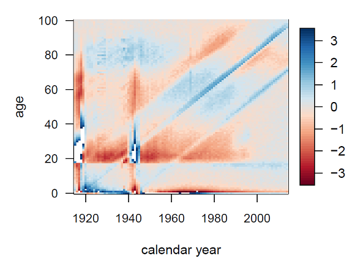

## Parallel Approaches

- Life Expectancy Forecast:
  - Oeppen and Vaupel (2002)
    - Torri and Vaupel (2012)
    - Lee (2006)
    - Raftery et al. (2013)
    - Pascariu et al. (2018)
- Age at Death distribution
  - Basellini and Camarda (2019)
  - Pascariu et al. (2018)

## Parsimony

- Parsimony criterion… Simple is better than complex

[figure not shown]

## Oeppen and Vaupel 2002

- Oeppen and Vaupel 2002 they show a remarkable linear trend in the female life expectancy (at birth, period basis), from 1840 to 2000.
- Over this entire 160-year period, the record life expectancy consistently increased by 0.24 years of life per calendar year of time.

[figure not shown]

## Key Message:

- Key Message:… rate of 24 years per century

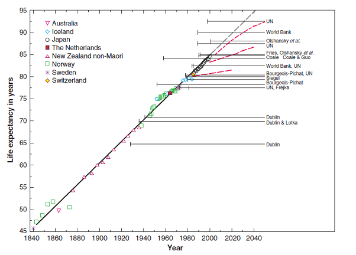

## Thank you

A big thanks to all “European Doctoral School of Demography” lecturers and my supervisors in Sapienza as well. Part of this presentation has been freely inspired by courses attended during my EDSD, the other one came from my direct research experience. It goes without saying that I am uniquely responsible for any deficiencies and mistakes you may find. For any request, advice, mistakes reporting or improvements, feel free to contact me at andrea.nigri@uniroma1.it

## Appendix

## Lee- Carter Vs. Renshaw Haberman (StMoMo Code)

```r
library(StMoMo)

# -----------------  Dati ITALIA  --------------------#

age=c(60:90)
ex_italia =read.csv("Ex_ITALIA.csv",header=TRUE,sep=";")[,-1][,-43][age,]
qx_italia=read.csv("qx.csv",header=TRUE,sep=";")[age,]
mx_italia <- -log(1-qx_italia)
dx_italia <- mx_italia*ex_italia
yv=c(1974:2015)
wxt <- genWeightMat(ages = age, years = yv, clip = 3)

#--------------------- mortality reduction factors --------------#
qx_RF <- matrix(0, nrow=length(age), ncol=(length(yv)-1))  # reduction factors
    for(i in 1:(length(yv)-1)){
        qx_RF[,i] <- qx_italia[,i+1]/qx_italia[,i]
    }
```

```r
#----------------   Heatmap RF  ---------------------#
require(grDevices) # for colours
require(graphics)
library(lattice)
Y <- as.numeric(yv[2:length(yv)])
A <- as.numeric(age)
par(mar=c(5,5,5,5))
filled.contour(A, Y, qx_RF, color.palette = colorRampPalette(c("white", "yellow", "orange", "red", "blue", "darkblue", "black"), space = "Lab"),
plot.title = title(main = "Mortality reduction factors", xlab = "età", ylab = "anni"),
plot.axes = {
    axis(1, seq(A[1], A[length(A)], by = 5))
    axis(2, seq(Y[1], Y[length(Y)], by = 5))
    },
key.title = title(main=""),
key.axes = axis(4, seq(min(qx_RF), max(qx_RF), by = ((max(qx_RF)-min(qx_RF))/20))))
```

```r
# -----------------  Modello Lee-Carter  --------------------#
LCfit <- fit(lc(), Dxt = dx_italia, Ext = ex_italia, ages = age, years = yv)
plot(LCfit)
names(LCfit)
BIC(LCfit); AIC(LCfit)
LCres <- residuals(LCfit)
plot(LCres, type="scatter")
plot(LCres, type = "signplot")
plot(LCres, type = "colourmap", reslim = c(-3.5, 3.5))

# The period indexes are forecasted using a Multivariate Random Walk with Drift (MRWD).
# The cohort index is forecasted using an ARIMA(p; d; q) . By default: ARIMA(1; 1; 0).
# h= number of years ahead to forecast
# level=  confidence level for prediction intervals of the period and cohort indices.
# jumpchoice option to select the jump-off rates, i.e. the rates from the final year of observation, to use in projections of mortality rates.
# "fit"(default) uses the fitted rates and  "actual" uses the actual rates from the final year.
# kt.lookback optional argument to specify the look-back window to use in the estimation of the MRWD for period indexes.
# By default all the estimated values are used in estimating the MRWD. If  kt.lookback is provided then the last  kt.lookback years of kt are used.
LCfor <- forecast(LCfit, h=50, level=95)    # proiezione
names(LCfor)
LCfor$rates
plot(LCfor)
```

```r
# -----------------  Modello Renshaw-Haberman  --------------------#
RHfit <- fit(rh(), Dxt = dx_italia, Ext = ex_italia, ages = age, years = yv)
RHres <- residuals(RHfit)
plot(RHres, type = "colourmap", reslim = c(-3.5, 3.5))
RHfor <- forecast(RHfit)
RHsim <- simulate(RHfit, nsim = 1000, h=50)

plot(LCfor, only.kt = TRUE)
plot(RHfor, only.kt = TRUE)
plot(RHfor, only.gc = TRUE)
```